# act

## **[PROJET - ACTUARIAT - VIE][Groupe G4-4 DS][Sujet - 3]**

[figure not shown]

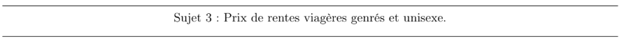

## Énoncé du sujet :

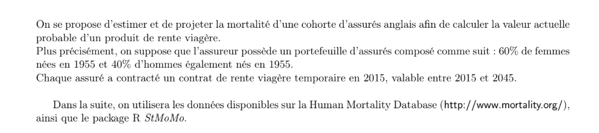

## Table of Contents

- Introduction
- Motivation Domaine Actuariat Vie
- Notre cas : -rente viagére differé et temporaire
- Notre Objectif
- Question 1 : Télécharger les données pour le pays concerné.
- Question 2 : En utilisant la procédure vue en cours pour estimer les taux de mortalité par maximum de vraisemblance, tracer les taux de mortalité en fonction de l’âge pour les deux cohortes concernées, pour les âges à partir de 2015. Tracer également les intervalles de confiance au seuil de 95%.
- Question 3 : Estimer les paramètres d’un modèle de Lee-Carter à partir des données historiques téléchargées (on pourra utiliser la fonction fit du package StMoMo). On prendra bien soin de :  
  — Commenter/justifier le choix de la plage d’âge et de la période choisie pour calibrer les données.  
  — Commenter les résultats obtenus en affichant les paramètres estimés.
- Question 4 : Afficher les log taux de mortalités historiques des hommes et des femmes à l’aide de la fonction extractcohort,et comparer avec les taux estimés en question 1.
- Question 5 : Estimer la projection centrale (moyenne) sur 25 ans des taux de mortalité à l’aide de la fonction forecast. A quelle quantité correspond la projection centrale ?
- Question 6 : Afficher les log taux de mortalités historiques et projetés pour les deux cohortes, à partir de 2005.
- Question 7 : Calculer la valeur actuelle probable du contrat (à la date de début du contract) en différenciant selon que l’assuré est un homme ou une femme. Qu’observe-t-on ?
- Question 8 : Un assureur peut-il différencier ses tarifs selon le genre de ses assurés ? Justifier. Recalculer la valeur de la prime pure du produit en ne prenant en compte que les données de la population global, sans différence de genre (série Total sur HMD).
- Question 9 : Proposer une autre méthode de tarification unisexe adapté au portefeuille de l’assureur. Quel transfert de risque observe-t-on ?
- **Optional :** Approfondissement du sujet et réponse aux questions d’ouverture : Provision pour reduire le risque (exemple)
- ressources bibliographique utilisées & "Références" :

**===> Dashboarb by R shiny**

# Introduction :

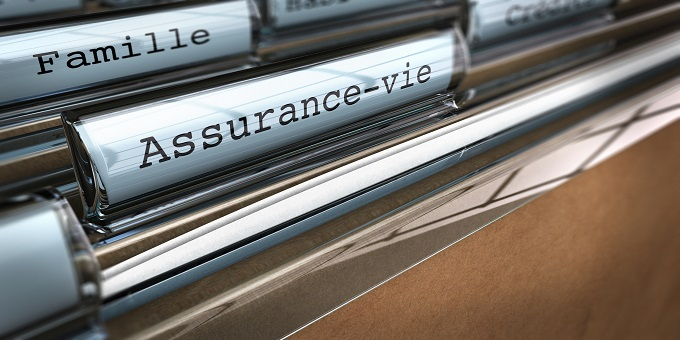

Grâce à l'émergence d'outils mathématiques, notamment le calcul probabiliste, le développement de l'assurance s'est poursuivi aux XVIIe et XVIIIe siècles . Il demeure alors possible qu'on mesure les paramètres du contrat d’assurance (tables de mortalité, risque de perte de l’assureur, rentes viagères ... ).

Comme son nom l'indique , "l’assurance vie" mplique la compensation de l’assuré en fonction du contrat à l'expiration (état : vivant ou mort). Il s'agit donc d'un contrat d'assurance, juste au cas de vie ou de décès. Ensuite , le risque de ce type de contrat est alors la durée de vie de l’assuré qu’il faut essayer d’estimer en utilisant les variables explicatives suivantes : age, sexe, catégorie socio-professionnelle...

Une fois l'espérance de vie estimée, il y aura une autre aléa à risque. En effet, dans de tels contrats, les échéances sont très longues. Ensuite, le montant de l'indemnisation dépend fortement du taux d'intérêt fourni Par le marché. Ces ratios sont également des sources de risques qui créent des risques. C'est le "Risque de taux d'intérêt"

Cette industrie de l'assurance-vie fait partie du domaine économique et réglementaire en plein mouvement et présentant des incertitudes croissantes pour plusieurs raisons , d'ou l'exigence des professionnel qui gèrent l'impact financier du risque et de l'incertitude.

Par conséquent, la tarification de ces contrats est basée sur deux points: la prédiction de la mortalité ainsi que la Mortalité. Dans cette étude rentrant dans un cadre académique, nous nous intéressons uniquement à la prévision de la mortalité .

Notre travail est de traiter le portefeuille d'un assureur composé d’assurés """anglais""" : 60% de femmes nées en 1955 et 40% d’hommes également nés en 1955.

cet étude consiste a la visualisation et la modélisation des 'taux de mortalité' par le modéle de 'Lee Carter' pour le Royaume-Uni (United Kingdom) , selon l'indice de développement humain , le U.K est classé parmi les pays ayant un niveau de vie parmi les plus élevés , ce modèle de prédiction nous méne a construire des tables de mortalité , en plus , peut intervenir dans des applications scientifiques actuarielles et dans la planification de régimes de retraite. Dans la section des résultats et des discussions, la méthodologie est illustrée par l’analyse des données sur la mortalité en united kingdom

processus : comment fonctionne l'assurance vie ? Dans cette section nous considérons un contrat d’assurance-vie selon lequel l’assuré (client) reçoit à chaque période un montant fixé au départ tant qu’il est en vie. Les montants payés sont appelés annuités viagères ou bien rentes viagères on s'intéresse aux Contrats différés et temporaires : un Contrat différé et temporaire est considéré comme un contrat dont il est différé de m année(s) et temporaire de n années. Cela signifie que l’assuré est indemnisé d’un montant unitaire chaque année entre les dates 'm' et 'm + n − 1' (en définissant la date de signature du contrat a 0) tant qu’il est vivant .

en fin ,tout cela va méner à projeter le taux de mortalité des cohortes concernés afin de d'adapter une tarification adéquate pour les assurés une tarification pour ce portefeuille par l’analyse et la prévision de résultats financiers des régimes de rente

# Question 1 :

## identification du pays concerné :

comme indiqué dans l'énoncé on va travailler sur un portefeuille d'un assureur composé d’assurés """anglais"""  
bien évidemment notre pays concerné c'est le

#### Royaume-Uni (United Kingdom)

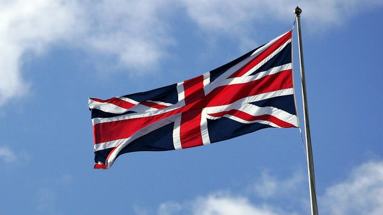

## Télechargement des donnés HMD : Téléchargement des données pour le pays concerné : le Royaume-Uni (United Kingdom)

[figure not shown]

On a téléchargé les données de mortalités (les taux bruts de mortalité ) a partir du site **[Human Mortality Database](https://www.mortality.org/cgi-bin/hmd/hmd_download.php)**.

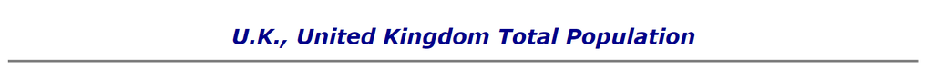

- les fichiers sont les suivants :
- - 1 : "Mx_1x1.txt" : Nom de fichier contenant les taux de mortalité démographiques
- - 2 : "Exposures_1x1" : Nom de fichier contenant l’exposition au rique

justification du notre choix : formats d'âge et de date doit être : par âge et par année (on va balayer tout les ages et tout les années un par un) , d'ou le choix des fichier format 1x1.

- pour cela on peut utiliser la commande hmd.mx() ou bien La fonction read.demogdata() qui lit les taux de mortalité et les effectifs sous risque.

```r
# chargement des librairies nécessaires :
library(forecast)
library(demography)
#library(MASS)
library(survival)
library(npsurv)
library(lsei)
library(fitdistrplus)
library(gnm)
library(StMoMo)
library(plotly)
library(ggplot2)
#library(lifecontingencies)
```

```r
# --- 1ére méthode : ----
# en utilisant la commande hmd.mx() : label U.K : "GBR_NP"
# hmd.mx : lit les données "Mx" (1x1) de la base de données sur la mortalité humaine et construit un objet demogdata
# hmd.pop : lit les données "Population" (1x1) du HMD et construit un objet demogdata
# help(hmd.mx)
DEATH = hmd.mx("GBR_NP", "wissal.khemiri@esprit.tn", "1586862810", label = "les taux démographiques - United Kingdom")
EXPOSURE = hmd.pop("GBR_NP", "wissal.khemiri@esprit.tn", "1586862810", label = "les numéros de population - United Kingdom")
# Warning des NAs introduits !
```

```r
# changement du dossier du travail et spécification du chemin d'accès au dossier souhaité (contenant les fichiers a utiliser)
setwd("C:/Users/LEGION/Desktop/Projet Actuariat/ok")
```

```r
# help(read.demogdata)
```

```r
# --- 2éme méthode : ----
# construction du demogdata du U.K , et dont le type d'objet est : «mortality» (car on va étudier des données de mortalité) :
demogUK <- read.demogdata(file="Mx_1x1.txt",
                           popfile="Exposures_1x1.txt",
                           type="mortality", label="United Kingdom Total Population")
```

```r
class(demogUK) # type vérifié
```

'demogdata'

```r
names(demogUK)
```

1. 'type'

2. 'label'

3. 'lambda'

4. 'year'

5. 'age'

6. 'rate'

7. 'pop'

```r
# résumé
summary(demogUK)
```

```
Mortality data for United Kingdom Total Population
    Series: female male total
    Years: 1922 - 2016
    Ages:  0 - 110
```

```r
# Manipulation des données HMD :
```

```r
# Affichage des objets demogdata :
```

#### les ages en axe des abscisses :

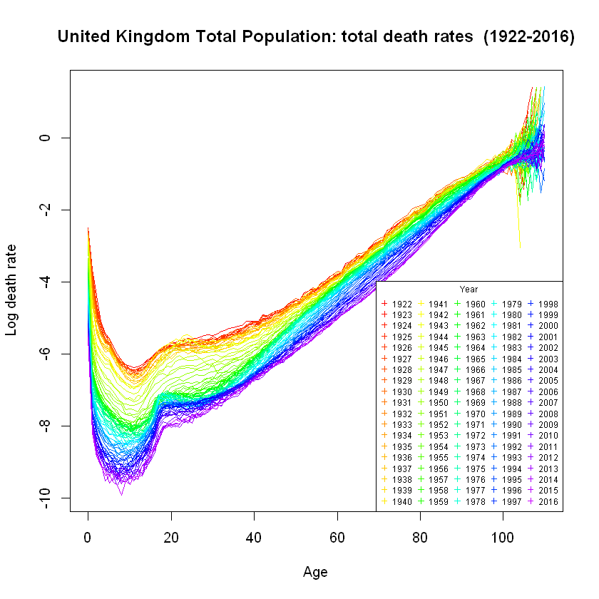

```r
# graph taux de mortalité de la polpulation total en fonction de l'age :
#par(mar=c(1, 1, 1, 1 ), xpd=TRUE)
plot(demogUK, series = 'total')
## avec légendes des années
legend("bottomright",legend=unique(demogUK$year),
       col=rainbow(length(demogUK$year)*1.25), ncol=5, pch=3,
       title="Year", cex=0.6 )
# ce plot exprime l'Evolution des taux de mortalité de l’ensemble de la population de Royaume-Uni entre les années 1922 a 2016 en fonction
# des ages"
```

```r
# on remarque que les taux de mortalité sont les plus élevés pour les âges extrêmes (les nouveaux nés / les personnes âgés )
```

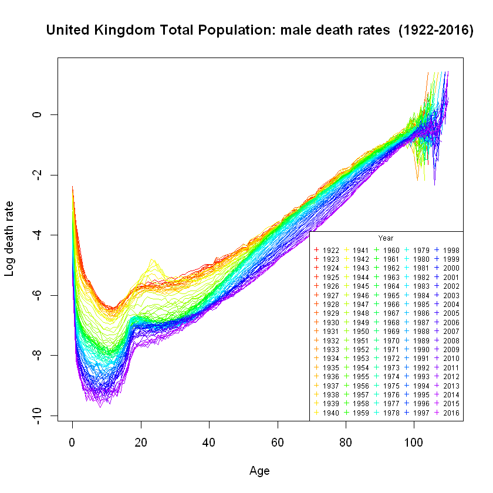

```r
# graph taux de mortalité de la polpulation masculine en fonction de l'age :
#par(mar=c(1, 1, 1, 1 ), xpd=TRUE)
plot(demogUK, series = 'male')
## avec légendes des années
legend("bottomright",legend=unique(demogUK$year),
       col=rainbow(length(demogUK$year)*1.25), ncol=5, pch=3,
       title="Year", cex=0.6 )
```

```r
# on remarque que les taux de mortalité sont les plus élevés pour les âges extrêmes (les nouveaux nés / les personnes âgés )
# La courbe de mortalité masculine présente une courbe en double cloche, avec un minimum, un maximum local, un minimum local et une croissance.
# Pour les hommes , on remarque une décroissance jusqu'a un niveau minimum des ageés de 10 ans puis croissance brusque et importante des années
# en couleur jaune (1939-1945) ce qui est expliqué par le décès de L'armée de terre britannique .
```

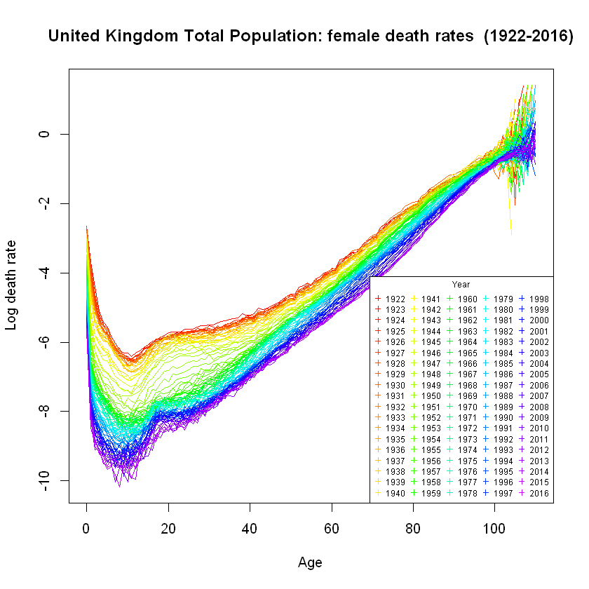

```r
# graph taux de mortalité de la polpulation féminine en fonction de l'age :
#par(mar=c(1, 1, 1, 1 ), xpd=TRUE)
plot(demogUK, series = 'female')
## avec légendes des années
legend("bottomright",legend=unique(demogUK$year),
       col=rainbow(length(demogUK$year)*1.25), ncol=5, pch=3,
       title="Year", cex=0.6 )
```

```r
# on remarque que les taux de mortalité sont les plus élevés pour les âges extrêmes (les nouveaux nés / les personnes âgés )
```

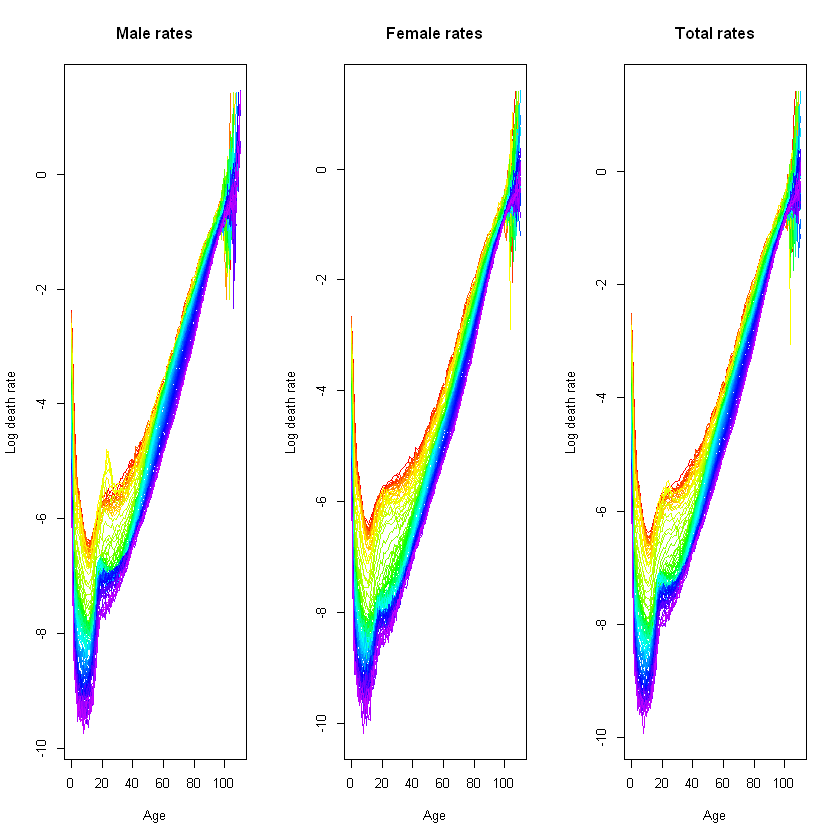

```r
# Affichage 'homme' VS 'femme' VS 'total' en fonction de l'age :
#par(mar=c(1, 1, 1, 1 ), xpd=TRUE)
par(mfrow=c(1,3))
plot(demogUK,series="male",datatype="rate", main="Male rates")
plot(demogUK,series="female",datatype="rate", main="Female rates")
plot(demogUK,"total",datatype="rate", main="Total rates")
```

Pour la population anglaise , ces graphes présentent les 3 schémas du logarithme des taux de mortalité en fonction de lâge . On remarque plusieurs comportements , on constate que :

- Les femmes sont également épargnées du pic de mortalité que la courbe rencontrée chez les hommes à la sortie de l’adolescence. Cela est probablement dû au fait que les normes culturelles imposent souvent aux hommes une tendance à prendre plus de risques pour s’affirmer à la sortie de l’adolescence .

```r
#taux de mortalité pour les années extemes : # on choisit d'utiliser la fct log pour linéariser nos graphics ==> type='l'
```

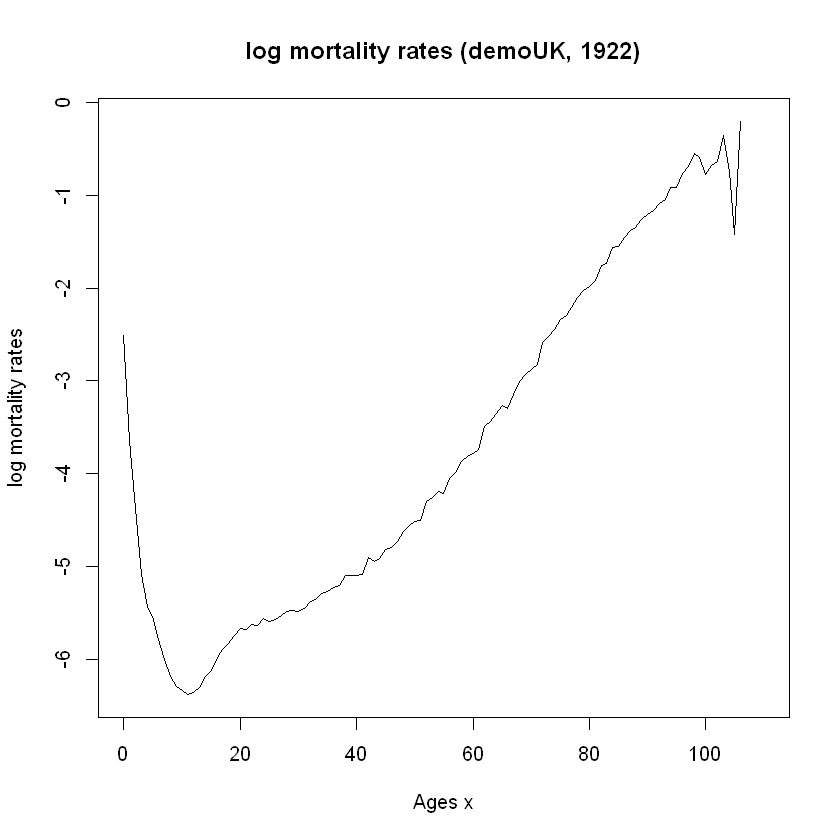

```r
# pour l'année 1922 :
plot(demogUK$age, log(demogUK$rate$total[,"1922"]), main ='log mortality rates (demoUK, 1922)',
     xlab = "Ages x", ylab = "log mortality rates", type = "l")
```

```r
# on remarque que les taux de mortalité sont les plus élevés pour les âges extrêmes (les nouveaux nés / les personnes âgés ) avec une croissance
# rapide a partir 30
```

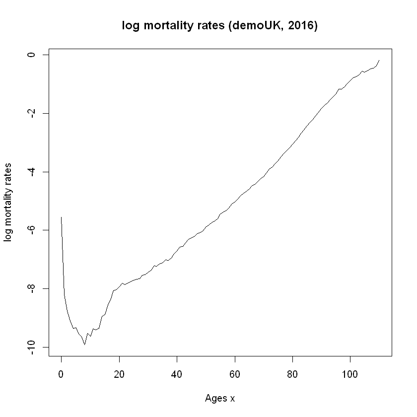

```r
# pour l'année 2016 :
plot(demogUK$age, log(demogUK$rate$total[,"2016"]), main ='log mortality rates (demoUK, 2016)',
     xlab = "Ages x", ylab = "log mortality rates", type = "l")
```

```r
# on remarque que les taux de mortalité sont les plus élevés pour les âges extrêmes (les nouveaux nés / les personnes âgés ) avec une croissance
# rapide a partir 30
```

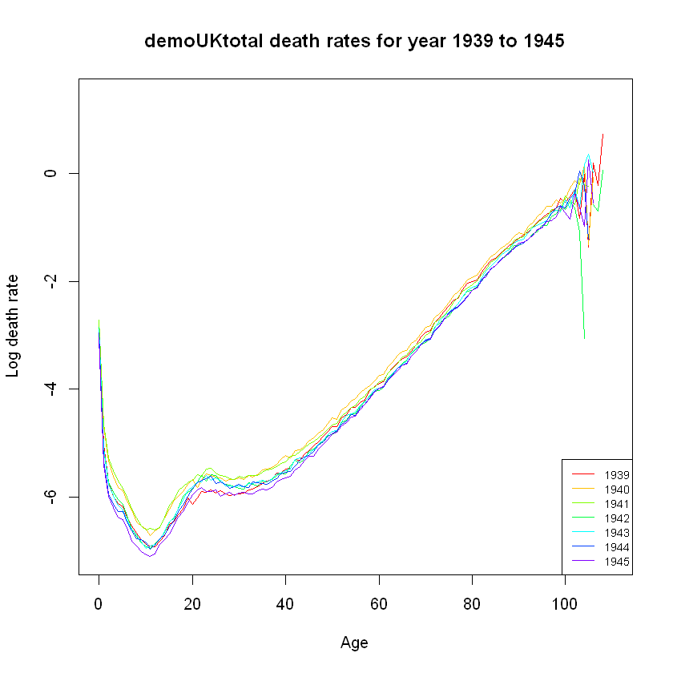

```r
# taux de mortalité pendant la 2éme guerre mondiale () :
UK_years = c(1939:1945)
plot(demogUK, series = 'total', years = UK_years ,
     main = "demoUKtotal death rates for year 1939 to 1945"
     )
legend(x="bottomright", legend = UK_years,
       col = rainbow(length(UK_years)*1.25),
       lty = 1,
       cex=0.7,
       box.lwd = 0.3
       )
```

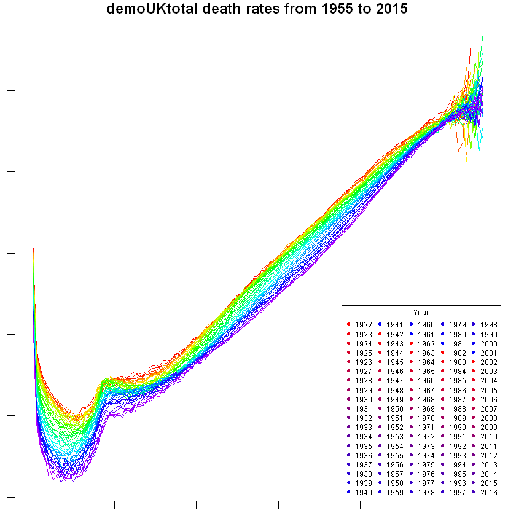

```r
# taux de mortalité entre les années 1955 au 2015 :
UK_years = c(1955:2015)
par(mar=c(1, 1, 1, 1 ), xpd=TRUE)
plot(demogUK, series = 'total', years = UK_years ,
     main = "demoUKtotal death rates from 1955 to 2015"
     )
colfunc <- colorRampPalette(c("red", "blue"))
legend(legend=unique(demogUK$year),
       col=colfunc(20), ncol=5, pch=19,
       title="Year", cex=0.6, "bottomright")
```

#### les années en axe des abscisses :

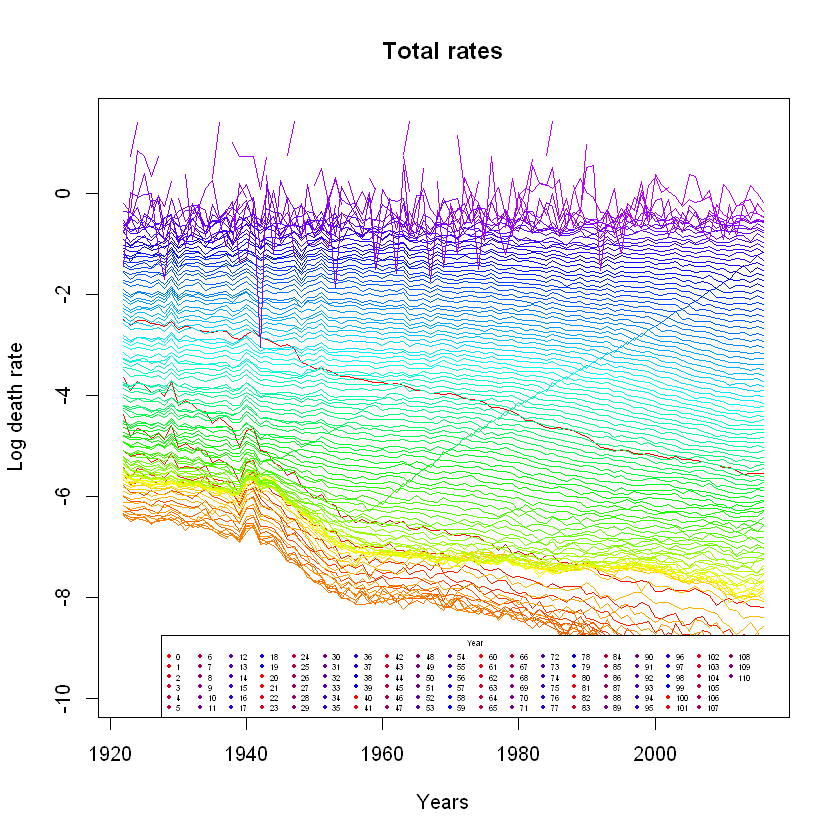

```r
# graph taux de mortalité de la polpulation totale en fonction des années :
plot(demogUK,"total",datatype="rate", main="Total rates",plot.type="time",xlab="Years")
legend(legend=unique(demogUK$age),
       col=colfunc(20), ncol=20, pch=19,
       title="Year", cex=0.4, "bottomright")
```

###### ########## observation population totale ################:

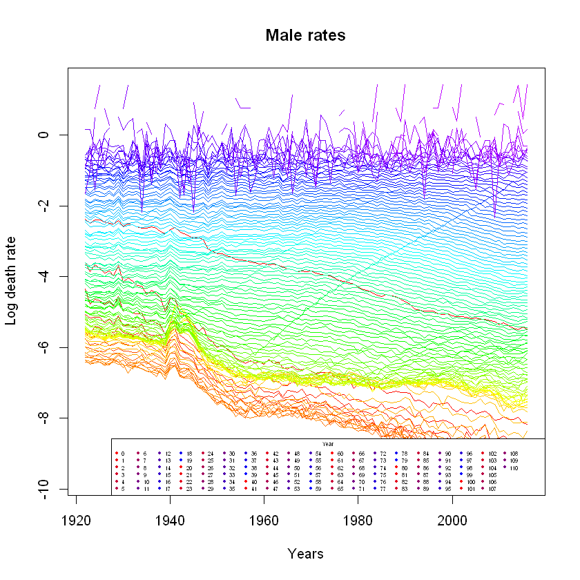

```r
# graph taux de mortalité de la polpulation masculine en fonction des années :
plot(demogUK,series="male",datatype="rate", plot.type="time", main="Male rates",xlab="Years")
legend(legend=unique(demogUK$age),
       col=colfunc(20), ncol=20, pch=19,
       title="Year", cex=0.4, "bottomright")
```

###### ########## observation population masculine ################:

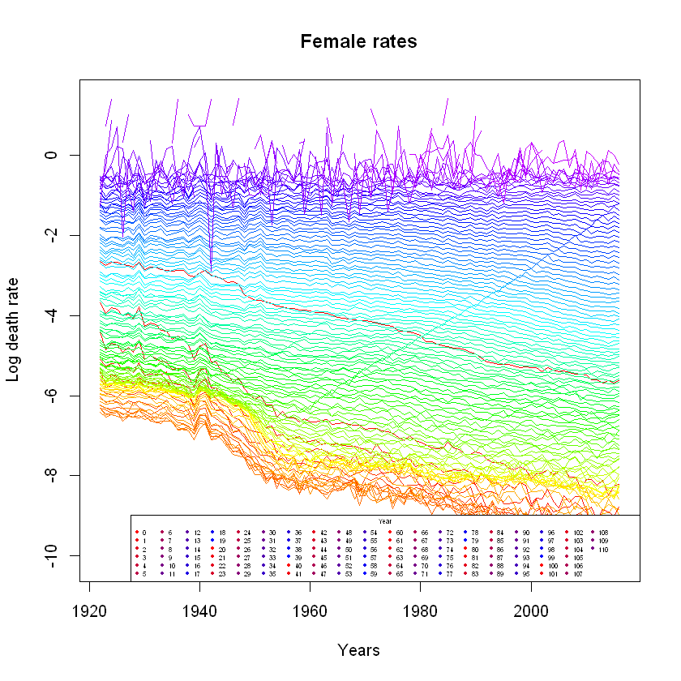

```r
# graph taux de mortalité de la polpulation féminine en fonction des années :
plot(demogUK,series="female",datatype="rate", main="Female rates",plot.type="time",xlab="Years")
legend(legend=unique(demogUK$age),
       col=colfunc(20), ncol=20, pch=19,
       title="Year", cex=0.4, "bottomright")
```

###### ########## observation population féminine ################:

```r
# Le log des taux de mortalité en fonction de l’âge et en fonction des années en 3D :
```

```r
demogUKlog = as.matrix(log(demogUK$rate$total))
demogUKlog[is.infinite(demogUKlog)]<-NA
library(ggplot2)
library(plotly)
p <- plot_ly(z = ~demogUKlog ) %>% add_surface()
#p
```

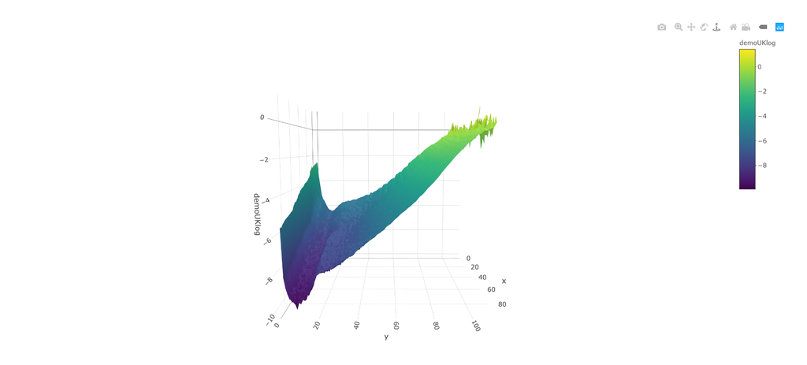

```r
# cette visualisation 3D représente mieux la différence entre les mortalités des différentes années de naissance.
```

# Question 2 :

En assurance vie, le principe est de suivre un individu par année de naissance pour pouvoir offir un produit d’assurance-vie pour les individus de la même génération. Ces trois dimensions $x$ (âge), $t$ (date) et $t − x$ (année de naissance) n’est pas sans rappeler la lecture des triangles de provisionnement $j$ (développement, ou âge d’un sinistre), $i+j$ (année calendaire, ou date de paiement) et $i$ (année de survenance, ou année de naissance du sinistre).

**Pour extraire une génération , nous avons récupéré la fonction suivante.**

```r
# NB : #taux de mortalité pour les années extemes : # on choisit d'utiliser la fct log pour linéariser nos graphics ==> type='l'
```

```r
cohort <- function(year, rates, log=FALSE)
{
  xg <- diag(rates[, colnames(rates) >= year])
  names(xg) <- paste(year, rownames(rates)[1:length(xg)], sep="-x=")
  if(log)
    xg <- log(xg)
  xg
}
```

```r
cohort_of_cohorts <- function(years, rates, log=FALSE)
{
  xgs<-vector()
  for (year in years)
  {
  xg <- diag(rates[, colnames(rates) >= year])
  names(xg) <- paste(year, rownames(rates)[1:length(xg)], sep="-x=")
  if(log)
    xg <- log(xg)
  xgs<-c(xgs,list(xg))
  }
  xgs
}
```

### Cohortes sur l'ensemble des années :

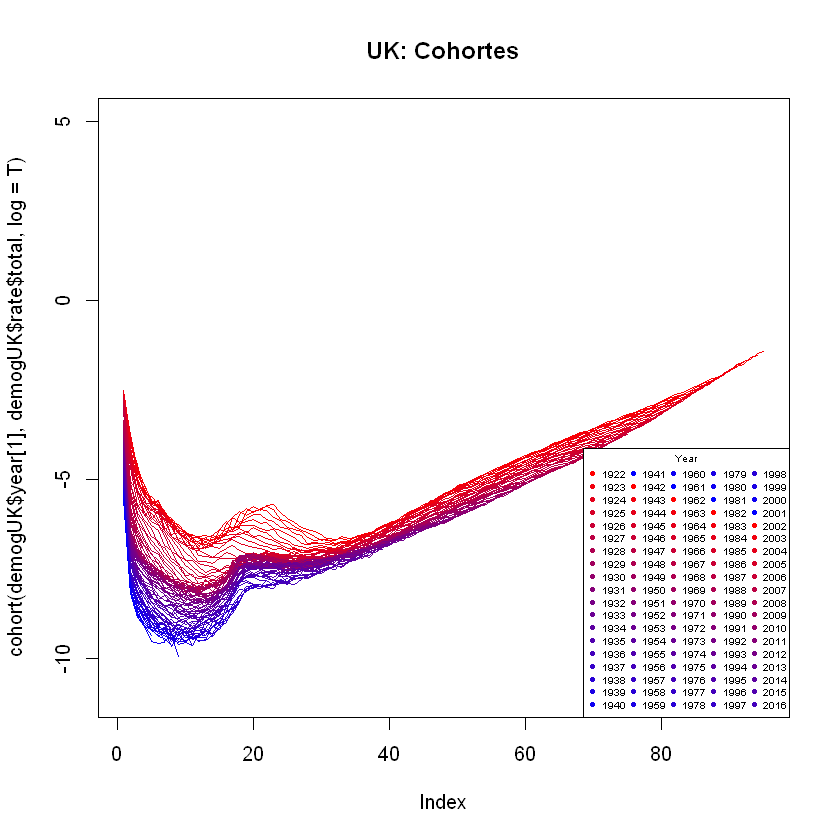

```r
colfunc <- colorRampPalette(c("red", "blue"))
cohorts<-cohort_of_cohorts(demogUK$year, demogUK$rate$total,  log=T)

plot(cohort(demogUK$year[1], demogUK$rate$total, log=T),col=colfunc(length(demogUK$year))[1], type="l", ylim=c(-11,5), main="UK: Cohortes")
i<-2
for (one_cohort in cohorts){
  lines (one_cohort, col=colfunc(length(demogUK$year))[i])
  i<-i+1
}
legend(legend=unique(demogUK$year),
       col=colfunc(20), ncol=5, pch=19,
       title="Year", cex=0.5, "bottomright")
```

### 1ére Cohorte : 60% de femmes nées en 1955 ayant contractés un contrat en 2015 :

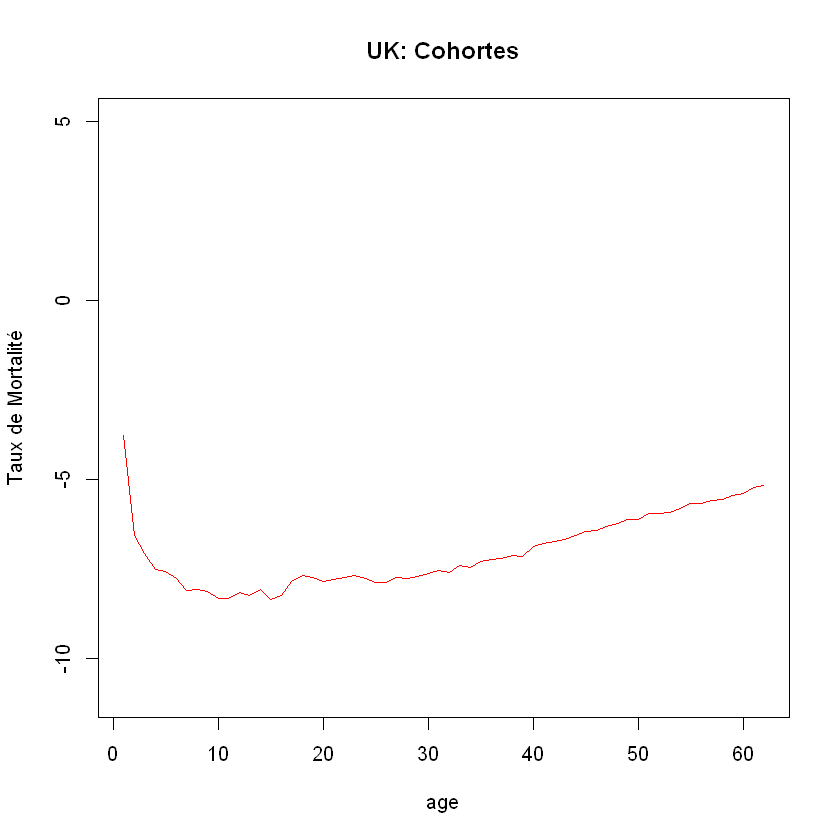

```r
plot(cohort(1955, demogUK$rate$female, log=T),
     col=colfunc(length(1955)),
     type="l",
     ylim=c(-11,5),
     main="UK: Cohortes",
     xlab = "age",
     ylab = "Taux de Mortalité")
```

```r
cohort1955_f <- cohort(1955, demogUK$rate$female)
```

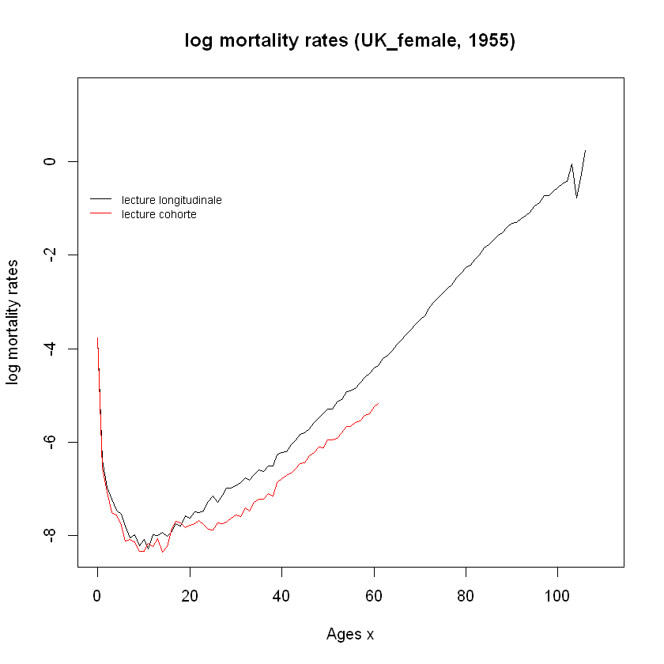

```r
plot(demogUK$age, log(demogUK$rate$female[,"1955"]), main ='log mortality rates (UK_female, 1955)',
     xlab = "Ages x", ylab = "log mortality rates", type = "l")

lines(0:(length(cohort1955_f)-1), log(cohort1955_f), main ='female log mortality rates (UK, 1955)',
      xlab = "Ages x", ylab = "log mortality rates", type = "l",col='red')

legend(-4, -0.5,legend = c("lecture longitudinale", "lecture cohorte"),
       col=c("black","red"),lty = 1, cex=0.7,
       box.lty = 0
)
```

```r
# On observe que pour l'année 1955 le taux de mortalité augmente rapidement contrairement pour la génération de 1955 pour l'age de 40 ans
# c'est a dire a partir de l'année 1995.
```

### 2éme Cohorte : 40% de hommes nées en 1955 ayant contractés un contrat en 2015 :

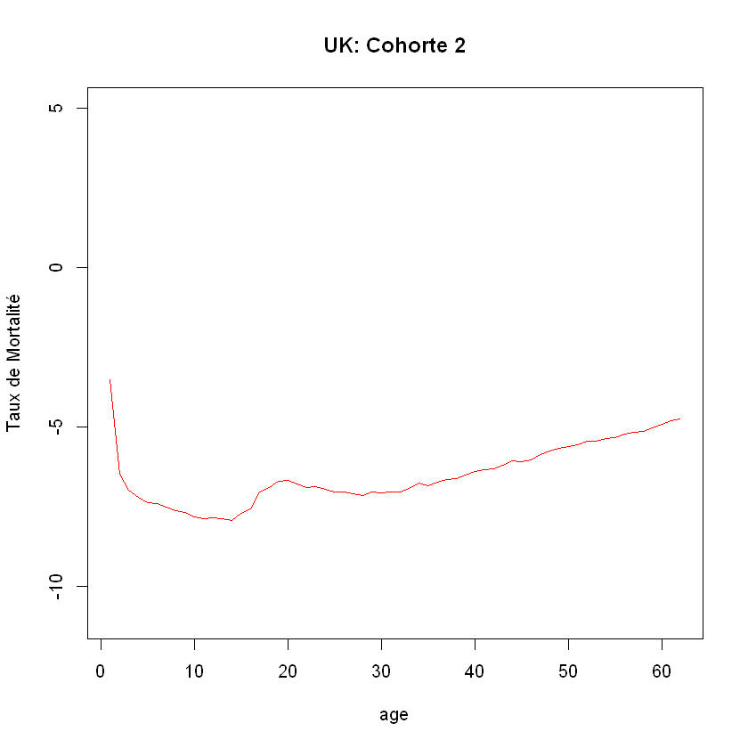

```r
plot(cohort(1955, demogUK$rate$male, log=T),
     col=colfunc(length(1955)),
     type="l",
     ylim=c(-11,5),
     main="UK: Cohorte 2",
     xlab = "age",
     ylab = "Taux de Mortalité")
```

```r
cohort1955_m <- cohort(1955, demogUK$rate$male, log=F)
```

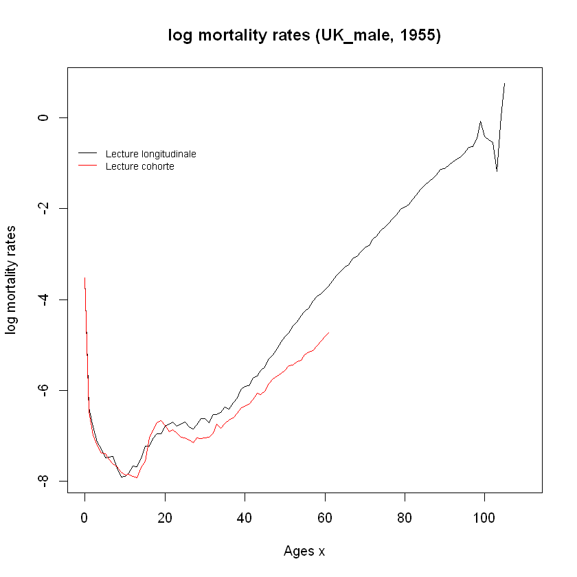

```r
plot(demogUK$age, log(demogUK$rate$male[,"1955"]), main ='log mortality rates (UK_male, 1955)',
     xlab = "Ages x", ylab = "log mortality rates", type = "l")

lines(0:(length(cohort1955_m)-1), log(cohort1955_m), main ='log mortality rates (UK, 1955)',
      xlab = "Ages x", ylab = "log mortality rates", type = "l",col='red')

legend(-4, -0.5,legend = c("Lecture longitudinale", "Lecture cohorte"),
       col=c("black","red"),lty = 1, cex=0.7,
       box.lty = 0
)
```

```r
# On observe que pour l'année 1955 le taux de mortalité augmente rapidement contrairement pour la génération de 1955 pour l'age de 40 ans
# c'est a dire a partir de l'année 1995.
```

```r
# 2éme tentative : IC : Réf : cour Monte Carlo :
```

```r
#library(MASS)
#help(fitdistr)
library(fitdistrplus)
library(survival)
library(npsurv)
library(lsei)
```

```r
fit.norm<-fitdist(cohort(1955, demogUK$rate$total, log=T), "norm" )
fit.norm$estimate
```

**mean**

-6.71793259584523

**sd**

0.961998855057646

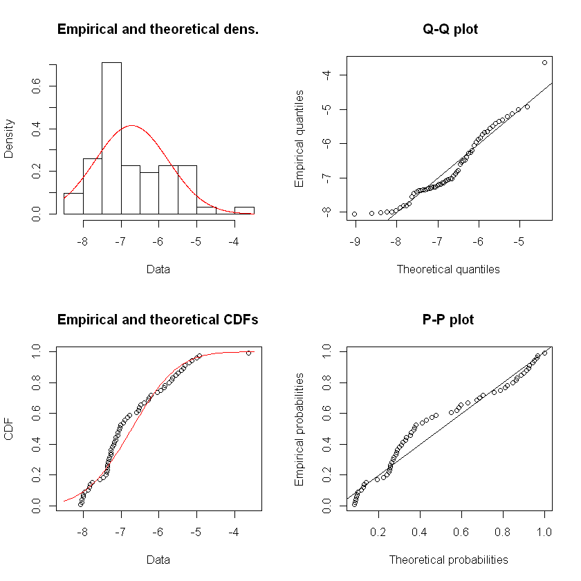

```r
plot(fit.norm)
```

- NB : Niveau de conﬁance de 95% ===> z(alpha/2)=1.96

```r
ect = fit.norm$estimate["sd"]
```

```r
moy_emp = fit.norm$estimate["mean"]
```

```r
IC_inf = moy_emp-1.96*ect/sqrt(2)
```

```r
IC_sup = moy_emp+1.96*ect/sqrt(2)
```

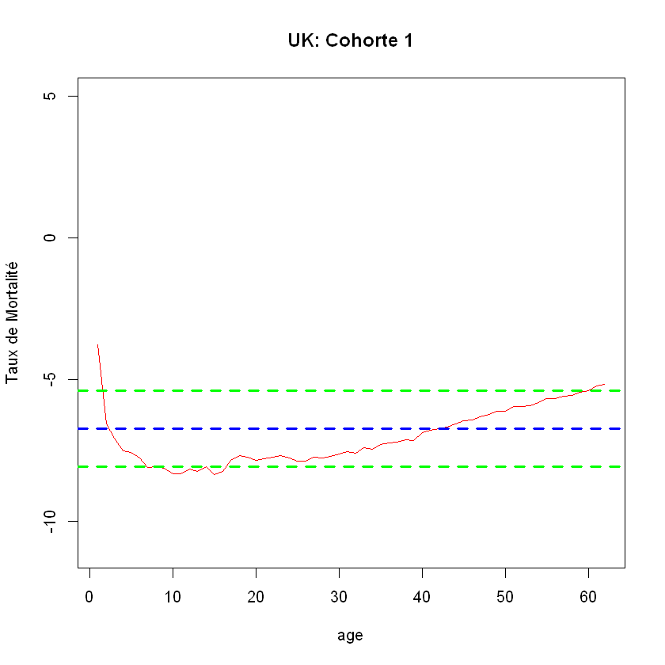

```r
plot(cohort(1955, demogUK$rate$female, log=T),
     col=colfunc(length(1955)),
     type="l",
     ylim=c(-11,5),
     main="UK: Cohorte 1",
     xlab = "age",
     ylab = "Taux de Mortalité")

abline(h=moy_emp,col="blue", lwd=3, lty=2)
abline(h=IC_inf,col="green", lwd=3, lty=2)
abline(h=IC_sup,col="green", lwd=3, lty=2)
```

```r
# 2éme tentative :
```

```r
DEATH = read.table(file="Mx_1x1.txt", header = TRUE,skip = 1, sep = "", dec = ".")
EXPOSURE = read.table(file="Exposures_1x1.txt", header = TRUE,skip = 1, sep = "", dec = ".")
```

```r
DEATH$Age=as.numeric(as.character(DEATH$Age))
DEATH$Age[is.na(DEATH$Age)]=110
```

```r
EXPOSURE$Age=as.numeric(as.character(EXPOSURE$Age))
EXPOSURE$Age[is.na(EXPOSURE$Age)]=110
```

```r
x=data.matrix(DEATH[,3:5])
```

```r
y=data.matrix(EXPOSURE[,3:5])
```

```r
ANNEE = c(1922:2016)
```

```r
AGE = c(0:110)
```

```r
MU=data.frame(x/y,row.names =(DEATH[,3:5])$rownames )
```

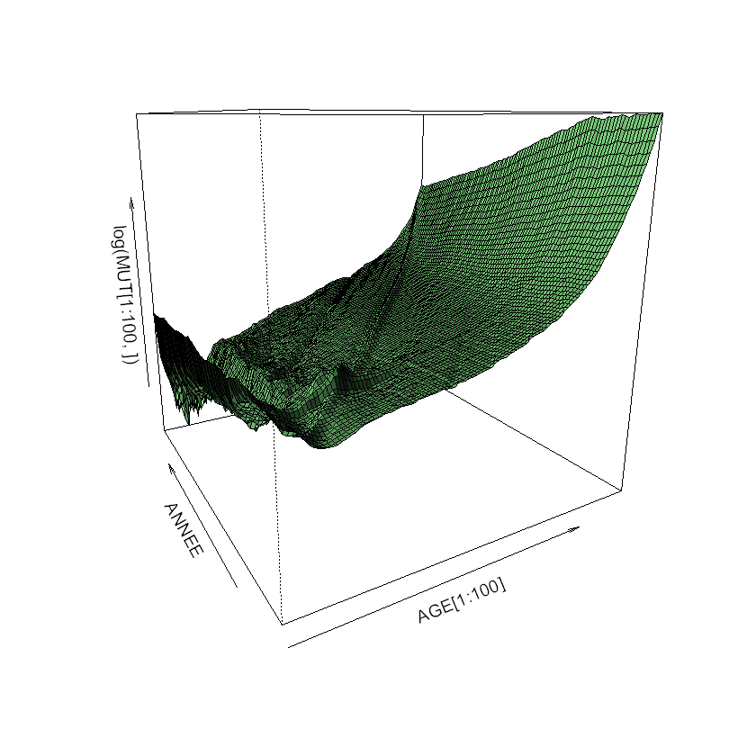

```r
MUT=matrix(MU[,3],length(AGE),length(ANNEE))
persp(AGE[1:100],ANNEE,log(MUT[1:100,]),theta=-30,col="light green",shade=TRUE)
```

```r
#YEAR=unique(DEATH['Year'])
YEAR = c(1922:2016)
nC=length(YEAR)
```

```r
AGE =unique(DEATH$Age)
nL=length(AGE)
```

```r
x=c(DEATH$Female)
y=c(EXPOSURE$Female)
```

```r
MUF =matrix(x/y,nL,nC)
```

```r
#MUF
```

```r
a=c(DEATH$Male)
b=c(EXPOSURE$Male)
```

```r
MUH = matrix(a/b,nL,nC)
```

```r
#MUH
```

```r
library(MASS)
library(rainbow)
library(pcaPP)
```

```r
#length(MUH)
```

```r
rownames(MUH)=AGE
```

```r
colnames(MUH)=YEAR
```

```r
rownames(MUF)=AGE
```

```r
colnames(MUF)=YEAR
```

```r
MUH=MUH[1:90,]
```

```r
MUF=MUF[1:90,]
```

```r
MUHF=fts(x = AGE[1:90], y = log(MUH), xname = "Age",yname = "Log Mortality Rate")
```

```r
MUFF=fts(x = AGE[1:90], y = log(MUF), xname = "Age",yname = "Log Mortality Rate")
```

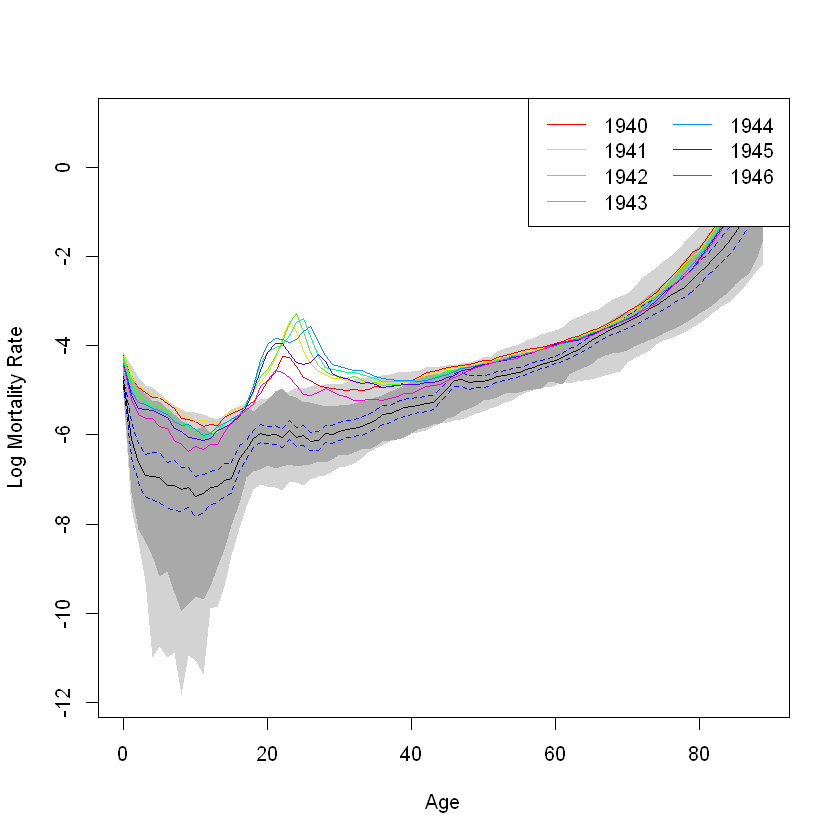

```r
fboxplot(data = MUHF, plot.type = "functional", type = "bag")
```

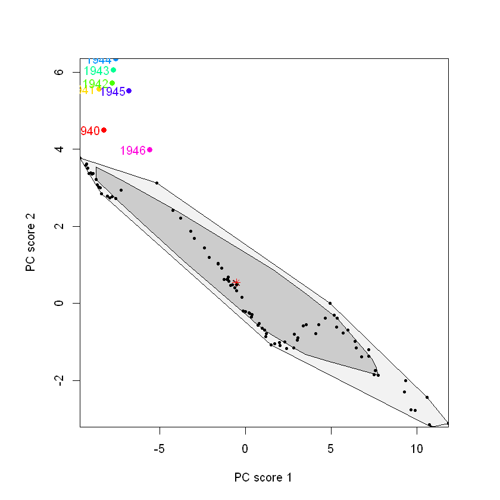

```r
fboxplot(data = MUHF, plot.type = "bivariate", type = "bag")
```

```r
# les années c(1940:1946) sont en dehors de l'inervalle de confiance entre les ages c(17:40)
```

### ref : intervalles de confiance : **[freakonometrics](http://freakonometrics.free.fr/slides-Rmetrics-2.pdf)**

# Question 3 : Modéle de Lee Carter :

```r
# affichage les taux de mortalité de certains ages en fonction des années
```

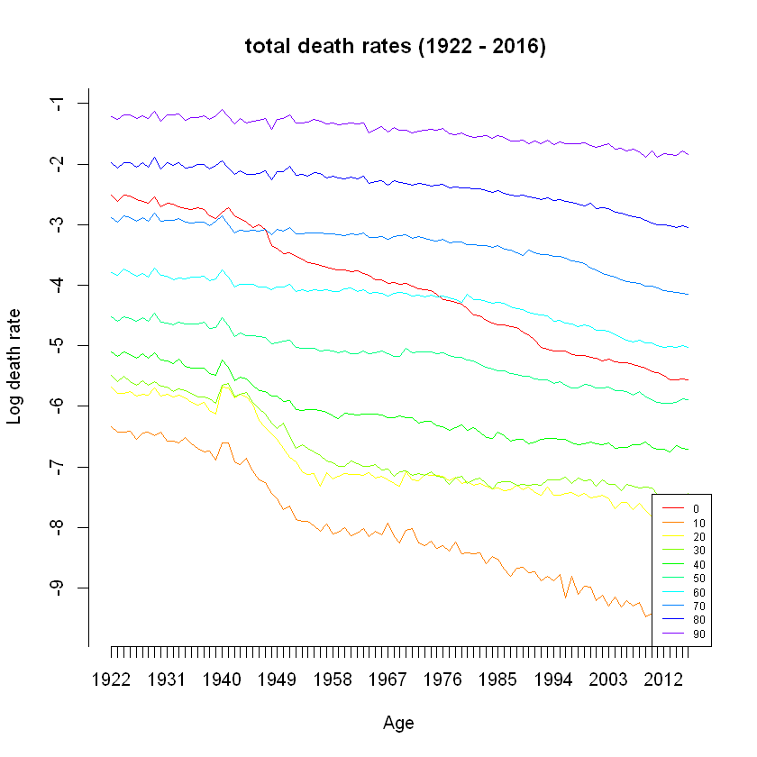

```r
# Choix de la période de calibration des données :
par(mfrow=c(1,1))
UK_ages = c(0,10,20,30,40,50,60,70,80,90)

plot(demogUK,
     series="total",
     datatype="rate",
     plot.type="time",
     age = UK_ages,
     main="total death rates (1922 - 2016) ",axes = F)
# on fixe les axes comme suit :
axis(side = 1, at=1922:2016)
axis(side = 2, at=-10:0)
legend(x="bottomright", legend = UK_ages,
       col = rainbow(length(UK_ages)*1.25), lty = 1, cex=0.6,
       box.lwd = 0.3)
```

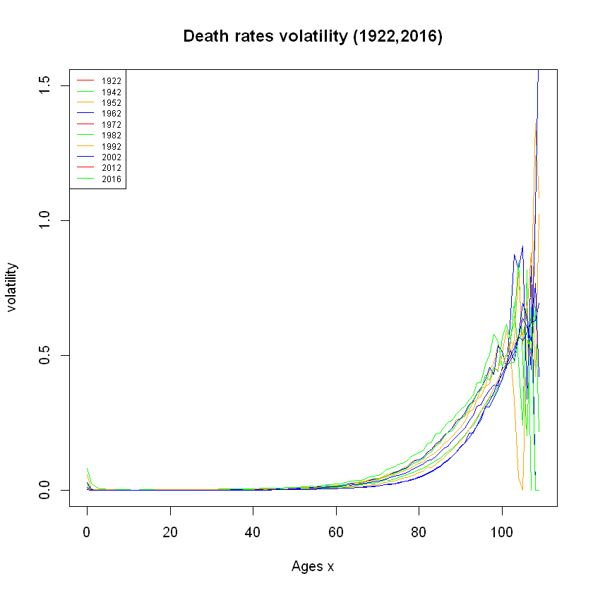

```r
# Choix de la plage d'âges:

x <- demogUK$age[0:110]


plot(x, demogUK$rate$total[0:110,"1922"],
     type='l',
     col='red',
     xlab= "Ages x",
     ylab="volatility",
     ylim=c(0,1.5),
     main ="Death rates volatility (1922,2016)")

lines(x, demogUK$rate$total[0:110,"1922"], type = 'l', col="green" )
lines(x, demogUK$rate$total[0:110,"1942"], type = 'l', col='orange' )
lines(x, demogUK$rate$total[0:110,"1952"], type = 'l', col="blue" )
lines(x, demogUK$rate$total[0:110,"1962"], type = 'l', col="green" )
lines(x, demogUK$rate$total[0:110,"1972"], type = 'l', col='orange' )
lines(x, demogUK$rate$total[0:110,"1982"], type = 'l', col="blue" )
lines(x, demogUK$rate$total[0:110,"1992"], type = 'l', col="green" )
lines(x, demogUK$rate$total[0:110,"2002"], type = 'l', col='orange' )
lines(x, demogUK$rate$total[0:110,"2012"], type = 'l', col="blue" )
lines(x, demogUK$rate$total[0:110,"2016"], type = 'l', col="blue" )


legend(x="topleft",
       legend = c("1922","1942","1952","1962","1972","1982","1992","2002","2012","2016"),
       col = c("red","green","orange","blue"),
       lty = 1,
       cex=0.6,
       box.lwd = 0.3)
```

- faute d'une forte variabilité des taux de mortalité pour les âges > 100 on va se limiter à choisir x ∈ [0, 100].

```r
#plage d'âges
ages.fit = 0:100
#période de calibration
years.fit = 1922:2016
```

```r
# Lissage :
```

```r
## 1- Spline monotone :
```

```r
demogUK_ls_m <- smooth.demogdata(demogUK,method="mspline")
```

```r
## 2- Spline standard :
```

```r
demogUK_ls_s <- smooth.demogdata(demogUK, method="spline")
```

```r
## 3- Spline Concave :
```

```r
demogUK_ls_c <- smooth.demogdata(demogUK, method="cspline")
```

```r
## 4- Spline localement quadratique :
```

```r
demogUK_ls_q <- smooth.demogdata(demogUK, method="loess")
```

```r
# comparaison :
```

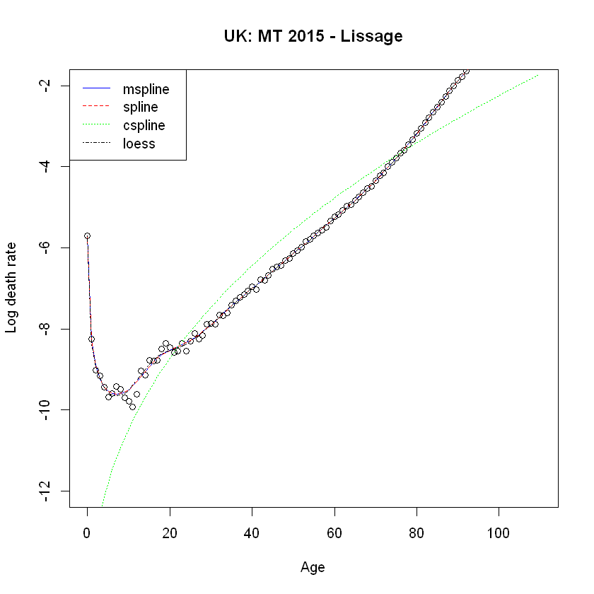

```r
plot(demogUK, years=2015, type="p", pch=21, ylim=c(-12, -2), main="UK: MT 2015 - Lissage")
lines(demogUK_ls_m, years=2015, lty=1, col="blue")
lines(demogUK_ls_s, years=2015, lty=2, col="red")
lines(demogUK_ls_c, years=2015, lty=3, col="green")
lines(demogUK_ls_q, years=2015, lty=4, col="black")
legend("topleft",col=c("blue","red","green","black") ,lty=1:4, leg=c("mspline", "spline","cspline","loess"))
```

```r
# fitting Lee Carter model :
```

```r
# séparation des jeux de données totaux, hommes et femmes :
```

```r
lca.total <- lca(demogUK_ls_m, series="total", adjust="dt",years =years.fit ,ages = ages.fit)
```

```r
lca.male <- lca(demogUK_ls_m, series="male", adjust="dt",years =years.fit ,ages = ages.fit)
```

```r
lca.female <- lca(demogUK_ls_m, series="female", adjust="dt",years =years.fit ,ages = ages.fit)
```